# cp2021-F09-Q02

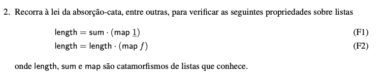

$\def\cata#1{\mathopen{(\!|}#1\mathclose{|\!)}}\def\kons#1{\underline{#1}}$

### Resolução (F1)

Sabendo que $length = \cata{[\kons{0},succ . \pi_2]}$ e que $sum = \cata{[\kons{0},add]}$

queremos mostrar que

$\cata{[\kons{0},succ . \pi_2]} = \cata{[\kons{0},add]} . (map \ \kons{1})$

{ $T \ f = T \ \kons{1} = map \ \kons{1})$ }

$\equiv \cata{[\kons{0},succ . \pi_2]} = \cata{[\kons{0},add]} . T \ \kons{1}$

{ **absorção-cata, lei (51)** }

$\equiv \cata{[\kons{0},succ . \pi_2]} = \cata{[\kons{0},add] . B \ (\kons{1},id)}$

{ $B(f,id) = id + f \times id$ }

$\equiv \cata{[\kons{0},succ . \pi_2]} = \cata{[\kons{0},add] . (id + \kons{1} \times id)}$

{ **absorção-+, lei (22); natural-id, lei (1)** }

$\equiv \cata{[\kons{0},succ . \pi_2]} = \cata{[\kons{0} ,add . (\kons{1} \times id)}$

{ $succ . \pi_2 = add . (\kons{1} \times id)$ }

$\equiv True$

**Nota**

$(succ . \pi_2) \ (a,b) = succ (b) = 1 + b$

$(add . (\kons{1} \times id)) \ (a,b) = add \ (\kons{1} \ a, b) = add \ (1,b) = 1 + b$

### Resolução (F2)

Sabendo que $length = \cata{[\kons{0},succ . \pi_2]}$

queremos mostrar que

$\cata{[\kons{0},succ . \pi_2]} = \cata{[\kons{0},succ . \pi_2]} . (map \ f)$

{ $T \ f = map \ f$ }

$\equiv \cata{[\kons{0},succ . \pi_2]} = \cata{[\kons{0},succ . \pi_2]} . T \ f$

{ **absorção-cata, lei (51)** }

$\equiv \cata{[\kons{0}, succ . \pi_2]} = \cata{[\kons{0}, succ . \pi_2] . B \ (f,id)}$

{ $B(f,id) = id + f \times id$ }

$\equiv \cata{[\kons{0},succ . \pi_2]} = \cata{[\kons{0}, succ . \pi_2] . (id + f \times id)}$

{ **absorção-+, lei (22); natural-id, lei (1)** }

$\equiv \cata{[\kons{0},succ . \pi_2]} = \cata{[\kons{0}, succ . \pi_2 . (f \times id)}$

{ **natural-**$\pi_2$ }

{ **natural-id, lei (1)** }

$\equiv True$